# Capstone Report - The Comparison of Neighborhoods

### Dharmesh Patel, 04 July 2020

1. Introduction: Business Problem
2. Data Source  
   Neighborhood data collection  
   Venue data collection using Foursquare API  
   Data wrangling and standardization
3. Methodology
4. Analysis  
   City level analysis  
   Neighborhood level analysis
5. Results and Discussion
6. Conclusion

## 1. Introduction:

### 1.1 Background

**Is New York City more like Toronto?**

*Whenever a person relocates to new city, they search for a suitable neighborhood. They are usually interested in knowing the different neighborhoods that the city has to offer, and find out the neighborhoods with specific venue or business of their interest, and compare the options. Combining the location and the information of venues near to neighborhood would help new people/business in a city to make better informed decisions and help them to choose neighborhood amongst the many neighborhood in the city.*

**Objective:** Primary objective of this project is to set up the process to compare neighborhood across geographical location, and provide results that help us to analyze how the selected cities and its neighborhoods compares to each other, Cities in terms of the likelihood of their neighborhoods and neighborhoods by kind of venues they offer, such as:

- Compare the cities in terms of the number of restaurants serving their favorite cuisine
- Compare neighborhoods which has venues of their choice like Gym, Park, Restaurant, Market etc.

### 1.2 Interested audience

*Specifically, this project will be targeted to people/business new to the selected city and interested in finding out the neighborhoods with specific venue or venues, and compare it with the other neighborhoods. It will also help analyze the businesses within city.*

**Scope:** Anyone who wants to know more about Toronto, Canada and New York city of America, and find out neighborhood having at least one top venue in following category: Gym, Park, Arts & Entertainment, Beach, Coffee Shop, Sports Bar, Market, Supermarket, Asian Restaurant, Indian Restaurant.

## 2. Data:

*Both the selected cities are very diverse and are the financial capitals of their respective countries, in order to compare neighborhoods and Venues across both these cities, I started with compiling address and location (longitude, latitude) data for each neighborhood of both cities.*

### 2.1 Neighborhood Data

*The Toronto city has 10 boroughs and 99 neighborhoods. I have compiled this data set by scraping the Toronto postcode from wikipedia webpage for neighborhood address and then geocode address using Python Geocoder to obtain coordinates of each neighborhood: [github repositiry](https://github.com/Dharmeshpatel25Sep/Coursera-Capstone)*

```python
# Clean neighborhood data of Toronto city
```

```
The Toronto city has 10 boroughs and 99 neighborhoods.

 # of Neighborhoods in each Borough:

            Borough  Neighborhood
6        North York            20
1  Downtown Toronto            19
7       Scarborough            17
4         Etobicoke            12
0   Central Toronto             9
8      West Toronto             6
2      East Toronto             5
3         East York             5
9              York             5
5       Mississauga             1
```

|  | City | Borough | Neighborhood | Latitude | Longitude |
| --- | --- | --- | --- | --- | --- |
| 0 | Toronto | North York | Parkwoods | 43.753259 | -79.329656 |
| 1 | Toronto | North York | Victoria Village | 43.725882 | -79.315572 |
| 2 | Toronto | Downtown Toronto | Regent Park, Harbourfront | 43.654260 | -79.360636 |
| 3 | Toronto | North York | Lawrence Manor, Lawrence Heights | 43.718518 | -79.464763 |
| 4 | Toronto | Downtown Toronto | Queen's Park, Ontario Provincial Government | 43.662301 | -79.389494 |
| 5 | Toronto | Etobicoke | Islington Avenue, Humber Valley Village | 43.667856 | -79.532242 |
| 6 | Toronto | Scarborough | Malvern, Rouge | 43.806686 | -79.194353 |

```python
# Clean neighborhood data of New York city.
```

```
The New York city has 5 boroughs and 302 neighborhoods.

 # of Neighborhoods in each Borough:

         Borough  Neighborhood
3         Queens            80
1       Brooklyn            70
4  Staten Island            60
0          Bronx            52
2      Manhattan            40
```

|  | City | Borough | Neighborhood | Latitude | Longitude |
| --- | --- | --- | --- | --- | --- |
| 0 | New York | Bronx | Wakefield | 40.894705 | -73.847201 |
| 1 | New York | Bronx | Co-op City | 40.874294 | -73.829939 |
| 2 | New York | Bronx | Eastchester | 40.887556 | -73.827806 |
| 3 | New York | Bronx | Fieldston | 40.895437 | -73.905643 |
| 4 | New York | Bronx | Riverdale | 40.890834 | -73.912585 |
| 5 | New York | Bronx | Kingsbridge | 40.881687 | -73.902818 |
| 6 | New York | Manhattan | Marble Hill | 40.876551 | -73.910660 |

```python
# Appended data of both the cities, in order to fetch venue details for each neighborhood at once from Foursquare's API.
```

```
The data includes 2 cities 15 boroughs and 401 neighborhoods.

 # of Neighborhoods in each Borough:

        City           Borough  Neighborhood
3   New York            Queens            80
1   New York          Brooklyn            70
4   New York     Staten Island            60
0   New York             Bronx            52
2   New York         Manhattan            40
11   Toronto        North York            20
6    Toronto  Downtown Toronto            19
12   Toronto       Scarborough            17
9    Toronto         Etobicoke            12
5    Toronto   Central Toronto             9
13   Toronto      West Toronto             6
7    Toronto      East Toronto             5
8    Toronto         East York             5
14   Toronto              York             5
10   Toronto       Mississauga             1
```

### 2.2 Foursquare API Data

- *From Foursquare’s explore API, I fetched all venues (up to 100) within 500 meter radius of neighborhood's geographical location and collected their names, categories and locations (latitude and longitude). I will be using this data to analyze neighborhoods having similar kind of venues and explore similar venues with in city.*
- *From Foursquare's categories API, I retrieved mapping data for mapping venue to general category such as spot for Food, Entertainment etc.*
  - Foursquare’s explore API : https://api.foursquare.com/v2/venues/explore?
  - Foursquare's categories API : https://api.foursquare.com/v2/venues/categories?

*Note: Dataset retrieved from API is imported to CSV files, which are available at my Git hub repositiry: [github repositiry](https://github.com/Dharmeshpatel25Sep/Coursera-Capstone)*

```python
# Venue data for each neighborhood of both cities.
```

|  | City | Neighborhood | Neighborhood Latitude | Neighborhood Longitude | Venue | Venue Latitude | Venue Longitude | Venue Category | Venue Categoryid |
| --- | --- | --- | --- | --- | --- | --- | --- | --- | --- |
| 0 | New York | Wakefield | 40.894705 | -73.847201 | Lollipops Gelato | 40.894123 | -73.845892 | Dessert Shop | 4bf58dd8d48988d1d0941735 |
| 1 | New York | Wakefield | 40.894705 | -73.847201 | Walgreens | 40.896528 | -73.844700 | Pharmacy | 4bf58dd8d48988d10f951735 |
| 2 | New York | Wakefield | 40.894705 | -73.847201 | Carvel Ice Cream | 40.890487 | -73.848568 | Ice Cream Shop | 4bf58dd8d48988d1c9941735 |
| 3 | New York | Wakefield | 40.894705 | -73.847201 | Rite Aid | 40.896649 | -73.844846 | Pharmacy | 4bf58dd8d48988d10f951735 |
| 4 | New York | Wakefield | 40.894705 | -73.847201 | Dunkin' | 40.890459 | -73.849089 | Donut Shop | 4bf58dd8d48988d148941735 |
| 5 | New York | Wakefield | 40.894705 | -73.847201 | Shell | 40.894187 | -73.845862 | Gas Station | 4bf58dd8d48988d113951735 |
| 6 | New York | Wakefield | 40.894705 | -73.847201 | Subway | 40.890468 | -73.849152 | Sandwich Place | 4bf58dd8d48988d1c5941735 |
| 7 | New York | Wakefield | 40.894705 | -73.847201 | Central Deli | 40.896728 | -73.844387 | Deli / Bodega | 4bf58dd8d48988d146941735 |
| 8 | New York | Wakefield | 40.894705 | -73.847201 | Koss Quick Wash | 40.891281 | -73.849904 | Laundromat | 52f2ab2ebcbc57f1066b8b33 |
| 9 | New York | Co-op City | 40.874294 | -73.829939 | NaN | NaN | NaN | NaN | NaN |
| 10 | New York | Eastchester | 40.887556 | -73.827806 | Fish & Ting | 40.885656 | -73.829197 | Caribbean Restaurant | 4bf58dd8d48988d144941735 |
| 11 | New York | Eastchester | 40.887556 | -73.827806 | Cozy Cottage Restaurant | 40.886332 | -73.827616 | Diner | 4bf58dd8d48988d147941735 |
| 12 | New York | Eastchester | 40.887556 | -73.827806 | Mario's Pizza | 40.888628 | -73.831260 | Pizza Place | 4bf58dd8d48988d1ca941735 |
| 13 | New York | Eastchester | 40.887556 | -73.827806 | Dyre Fish Market | 40.889318 | -73.831453 | Seafood Restaurant | 4bf58dd8d48988d1ce941735 |
| 14 | New York | Eastchester | 40.887556 | -73.827806 | Dunkin' | 40.885384 | -73.828099 | Donut Shop | 4bf58dd8d48988d148941735 |

*Next, I created table for **mapping venue category** to generalize category such as spot for Food , Entertainment, Nightlife etc.*

```python
# Venue category mapping dataframe
```

|  | Categoryid_id | Category | Fine Category | Fine_Catid |
| --- | --- | --- | --- | --- |
| 20 | 4d4b7104d754a06370d81259 | Arts & Entertainment | Museum | 4bf58dd8d48988d181941735 |
| 40 | 4d4b7105d754a06372d81259 | College & University | College Cafeteria | 4bf58dd8d48988d1a1941735 |
| 60 | 4d4b7105d754a06373d81259 | Event | Conference | 5267e4d9e4b0ec79466e48c6 |
| 80 | 4d4b7105d754a06374d81259 | Food | Bangladeshi Restaurant | 5e179ee74ae8e90006e9a746 |
| 100 | 4d4b7105d754a06374d81259 | Food | Dumpling Restaurant | 4bf58dd8d48988d108941735 |

### 2.3 Data Wrangling:

*Now, We have comprehensive data set for neighborhoods of both the cities along with venues category. so I decided to explore the data and check that we have required data for analysis and standardize it for further analysis.*

- Checked data for duplicates, missing or miscellaneous values and cleaned it
- Created dataframe for unique venues with in city
- Created dataframe to overview the top 10 venue categories for each neighborhood

```python
# Removed neighborhoods which has no venue available nearby.
```

|  | City | Borough | Neighborhood | Neighborhood Latitude | Neighborhood Longitude | Venue | Venue Latitude | Venue Longitude | Venue Category | Venue Categoryid |
| --- | --- | --- | --- | --- | --- | --- | --- | --- | --- | --- |
| 9 | New York | Bronx | Co-op City | 40.874294 | -73.829939 | NaN | NaN | NaN | NaN | NaN |
| 11703 | Toronto | Downtown Toronto | Stn A PO Boxes | 43.646435 | -79.374846 | NaN | NaN | NaN | NaN | NaN |

```python
# Replaced miscellaneous value found for venue category like neighborhood shown below.
```

|  | City | Borough | Neighborhood | Neighborhood Latitude | Neighborhood Longitude | Venue | Venue Latitude | Venue Longitude | Venue Category | Venue Categoryid |
| --- | --- | --- | --- | --- | --- | --- | --- | --- | --- | --- |
| 1352 | New York | Brooklyn | Brighton Beach | 40.576825 | -73.965094 | Brighton Beach | 40.575518 | -73.962372 | Neighborhood | 4f2a25ac4b909258e854f55f |
| 2488 | New York | Brooklyn | Gerritsen Beach | 40.590848 | -73.930102 | Gerritsen Beach | 40.592377 | -73.925009 | Neighborhood | 4f2a25ac4b909258e854f55f |
| 9947 | New York | Queens | Hammels | 40.587338 | -73.805530 | Rockaway Beach, NY | 40.585899 | -73.809066 | Neighborhood | 4f2a25ac4b909258e854f55f |
| 10313 | Toronto | East Toronto | The Beaches | 43.676357 | -79.293031 | Upper Beaches | 43.680563 | -79.292869 | Neighborhood | 4f2a25ac4b909258e854f55f |

```python
# View clean neighborhood data with venues detail.
```

|  | City | Borough | Neighborhood | Neighborhood Latitude | Neighborhood Longitude | Venue | Venue Latitude | Venue Longitude | Venue Category | Venue Categoryid |
| --- | --- | --- | --- | --- | --- | --- | --- | --- | --- | --- |
| 0 | New York | Bronx | Wakefield | 40.894705 | -73.847201 | Lollipops Gelato | 40.894123 | -73.845892 | Dessert Shop | 4bf58dd8d48988d1d0941735 |
| 1 | New York | Bronx | Wakefield | 40.894705 | -73.847201 | Walgreens | 40.896528 | -73.844700 | Pharmacy | 4bf58dd8d48988d10f951735 |
| 2 | New York | Bronx | Wakefield | 40.894705 | -73.847201 | Carvel Ice Cream | 40.890487 | -73.848568 | Ice Cream Shop | 4bf58dd8d48988d1c9941735 |
| 3 | New York | Bronx | Wakefield | 40.894705 | -73.847201 | Rite Aid | 40.896649 | -73.844846 | Pharmacy | 4bf58dd8d48988d10f951735 |
| 4 | New York | Bronx | Wakefield | 40.894705 | -73.847201 | Dunkin' | 40.890459 | -73.849089 | Donut Shop | 4bf58dd8d48988d148941735 |

*In order to compare and see how the categories of venues are distributed in both the cities, I created new DataFrame having distinct list of all venues within city, as the venues data for each neighborhood will have duplicates entries for venue that falls in range of 500 meter of nearby or adjacent neighborhoods.*

```python
# Dataframe for unique venues with in city.
```

```
No of duplicates removed 914

Data of both city has total 11061 unique venues.

Unique venues data for city:
```

|  | City | Venue | Venue Latitude | Venue Longitude | Venue Category | Venue Categoryid |
| --- | --- | --- | --- | --- | --- | --- |
| 8378 | New York | Ghost Donkey | 40.725276 | -73.992492 | Cocktail Bar | 4bf58dd8d48988d11e941735 |
| 8942 | New York | Bumble & Bumble | 40.759903 | -73.969105 | Salon / Barbershop | 4bf58dd8d48988d110951735 |
| 9491 | New York | Time Out Market | 40.703421 | -73.992146 | Food Court | 4bf58dd8d48988d120951735 |
| 10072 | Toronto | 401 Games | 43.663623 | -79.384037 | Hobby Shop | 4bf58dd8d48988d1fb941735 |
| 10641 | Toronto | Papyrus | 43.648195 | -79.381392 | Gift Shop | 4bf58dd8d48988d128951735 |
| 11300 | Toronto | Pho 88 Vietnamese Cuisine | 43.770456 | -79.413064 | Vietnamese Restaurant | 4bf58dd8d48988d14a941735 |

*Next, I created new dataframe having one row for each neighborhood along with top 10 venue categories listed in columns. which I will use to classify and cluster neighborhoods., and then run our exploratory data analysis of neighborhood to determine the likelihood of neighborhoods.*

- Applied one hot encoding technique for venue category over venues dataframe
- Grouped it by neighborhood and took the mean frequency of the category occurrence

```python
# Print for overview of few neighborhoods.
```

```
Top 10 venue categories of neighborhood:

----- Allerton ------
                   vcat  freq
0           Pizza Place  0.14
1           Supermarket  0.10
2           Bus Station  0.07
3         Deli / Bodega  0.07
4        Breakfast Spot  0.03
5            Playground  0.03
6           Gas Station  0.03
7                   Spa  0.03
8                  Food  0.03
9  Fast Food Restaurant  0.03

```

[output cut: 25 more lines]

```python
# Dataframe to overview the top 10 venue categories for each neighborhood.
```

|  | City | Neighborhood | Latitude | Longitude | 1st Most Common Vcat | 2nd Most Common Vcat | 3rd Most Common Vcat | 4th Most Common Vcat | 5th Most Common Vcat | 6th Most Common Vcat | 7th Most Common Vcat | 8th Most Common Vcat | 9th Most Common Vcat | 10th Most Common Vcat |
| --- | --- | --- | --- | --- | --- | --- | --- | --- | --- | --- | --- | --- | --- | --- |
| 0 | New York | Allerton | 40.865788 | -73.859319 | Pizza Place | Supermarket | Bus Station | Deli / Bodega | Breakfast Spot | Dessert Shop | Bakery | Chinese Restaurant | Gym / Fitness Center | Gas Station |
| 1 | New York | Annadale | 40.538114 | -74.178549 | Pizza Place | Diner | Pub | Food | Cosmetics Shop | Train Station | Park | Sports Bar | Pharmacy | Deli / Bodega |
| 2 | New York | Arden Heights | 40.549286 | -74.185887 | Pizza Place | Deli / Bodega | Pharmacy | Coffee Shop | Dry Cleaner | Fish & Chips Shop | Financial or Legal Service | Duty-free Shop | Eastern European Restaurant | Egyptian Restaurant |
| 3 | New York | Arlington | 40.635325 | -74.165104 | Bus Stop | Furniture / Home Store | Intersection | Grocery Store | Deli / Bodega | Boat or Ferry | Eye Doctor | Exhibit | Event Space | Event Service |
| 4 | New York | Arrochar | 40.596313 | -74.067124 | Bus Stop | Italian Restaurant | Liquor Store | Deli / Bodega | Middle Eastern Restaurant | Supermarket | Pizza Place | Pharmacy | Bagel Shop | Mediterranean Restaurant |

## 3. Methodology:

**Data Collection:**  
*In first step, I have collected the required data for each neighborhood in both the cities: Address, location and type (category) of venues within 500 meter radius of Neighborhood location using Foursquare API.*

**Data Wrangling:**  
*Data I collected is comprehensive data set for neighborhoods of both the cities along with venues (up to 100). at this stage I explored the data & checked that I have data required for our analysis, and finally transformed it in standard format for further analysis.*

- Checked for duplicates, missing or miscellaneous values in data and cleaned it up
- Created dataframe for unique venues with in city
- Created dataframe to overview the top 10 venue categories for each neighborhood

> *Note: You may add some more neighborhood specific information in case to compare neighborhoods, such as distance of neighborhood from city center, airport, garden or from your business\home location. however, for this project we have used top 10 categories of venues that I have obtained from Foursquare API.*

*Now, I will move ahead in project and start with **Exploratory Data Analysis**.*

**City Level Analysis:**  
*I will analyse both the city according the % of venues falling in different categories. I will use the mapping table ('Categoriesmap_df') to map venue categories to general description such as Nightlife spot, Beach, Food etc. Further, I will plot the the number of restaurants serving different cuisine and types of food for both the cities and compare them.*

**Neighborhood Level Analysis:**  
*By now I will have explored New York and Toronto city, so I will start with segmentation and clustering of neighborhoods **(Data Classification: based on top 10 venue categories)** without filter of city. I will then explore few neighborhoods within city and find similar neighborhoods within\across city. and finally I will prepare map to showcase the similar neighborhoods based on specific neighborhood.*

*As a final step, I will analyse these plots and map and try to draw conclusions on how both the cities are similar or different. I will discuss my findings and any inferences I have draw so far.*

## 4. Exploratory Data Analysis:

### 4.1 City Level Analysis:

**Comparison of Cities based on Venue Characteristics**

*I begin my analysis by taking a look at the count and % of venues and various categories of venues that exist in both the city.*

```python
# Count of unique venues and categories.
```

```
# of Venues in:
New York    9422
Toronto     1639
Name: City, dtype: int64

There are 428 uniques categories of venues in New York, and 264 in Toronto.
```

*New York has way too more venues compare to Toronto, also seems there are more choices available in New York. To see how the venues categories are distributed. I mapped venue categories to more general category so I can compare it across city.*

```python
# Venues dataframe with genral category.
```

```
Check the last column of shown dataframe for genral category
```

|  | City | Venue | Venue Latitude | Venue Longitude | Venue Category | Venue Categoryid | Category |
| --- | --- | --- | --- | --- | --- | --- | --- |
| 0 | New York | Lollipops Gelato | 40.894123 | -73.845892 | Dessert Shop | 4bf58dd8d48988d1d0941735 | Food |
| 1 | New York | Walgreens | 40.896528 | -73.844700 | Pharmacy | 4bf58dd8d48988d10f951735 | Shop & Service |
| 2 | New York | Carvel Ice Cream | 40.890487 | -73.848568 | Ice Cream Shop | 4bf58dd8d48988d1c9941735 | Shop & Service |
| 3 | New York | Rite Aid | 40.896649 | -73.844846 | Pharmacy | 4bf58dd8d48988d10f951735 | Shop & Service |
| 4 | New York | Dunkin' | 40.890459 | -73.849089 | Donut Shop | 4bf58dd8d48988d148941735 | Food |

```python
# Category wise venues distribution across cities.
```

| # Venues Category | New York | Toronto |
| --- | --- | --- |
| Food | 4895.0 | 870.0 |
| Shop & Service | 2250.0 | 367.0 |
| Nightlife Spot | 587.0 | 105.0 |
| Outdoors & Recreation | 551.0 | 99.0 |
| Travel & Transport | 348.0 | 42.0 |
| Gym / Fitness Center | 308.0 | 42.0 |
| Arts & Entertainment | 255.0 | 53.0 |
| Professional & Other Places | 216.0 | 56.0 |

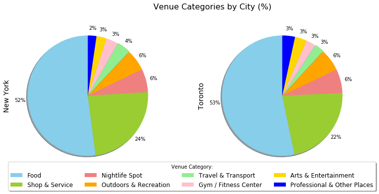

```python
# Pie Chart.
```

*It shows these cities are very similar and has almost identical contribution of venue categories. We can see difference of around 1-2 % for few venue categories. Although, New York has high number of venues compare to Toronto, which is expected due to different geographies and their coverage area. **The top 2 venue categories contributes to ~75% of venues, where ~52% venues falls in to Food and ~23% into Shop & Services category for both the cities.***

```python
# % of Restaurants serving different cuisine across cities.
```

| Cuisine City | Italian | Chinese | Mexican | American | Sushi | Fast Food | Japanese | Local | Thai | Latin American | Caribbean | Seafood |
| --- | --- | --- | --- | --- | --- | --- | --- | --- | --- | --- | --- | --- |
| New York | 12.1 | 8.8 | 7.4 | 6.5 | 4.6 | 4.0 | 3.7 | 3.5 | 3.5 | 3.4 | 3.3 | 3.0 |
| Toronto | 9.4 | 3.9 | 3.0 | 3.9 | 6.9 | 6.6 | 7.7 | 12.9 | 3.9 | 1.1 | 1.9 | 3.0 |

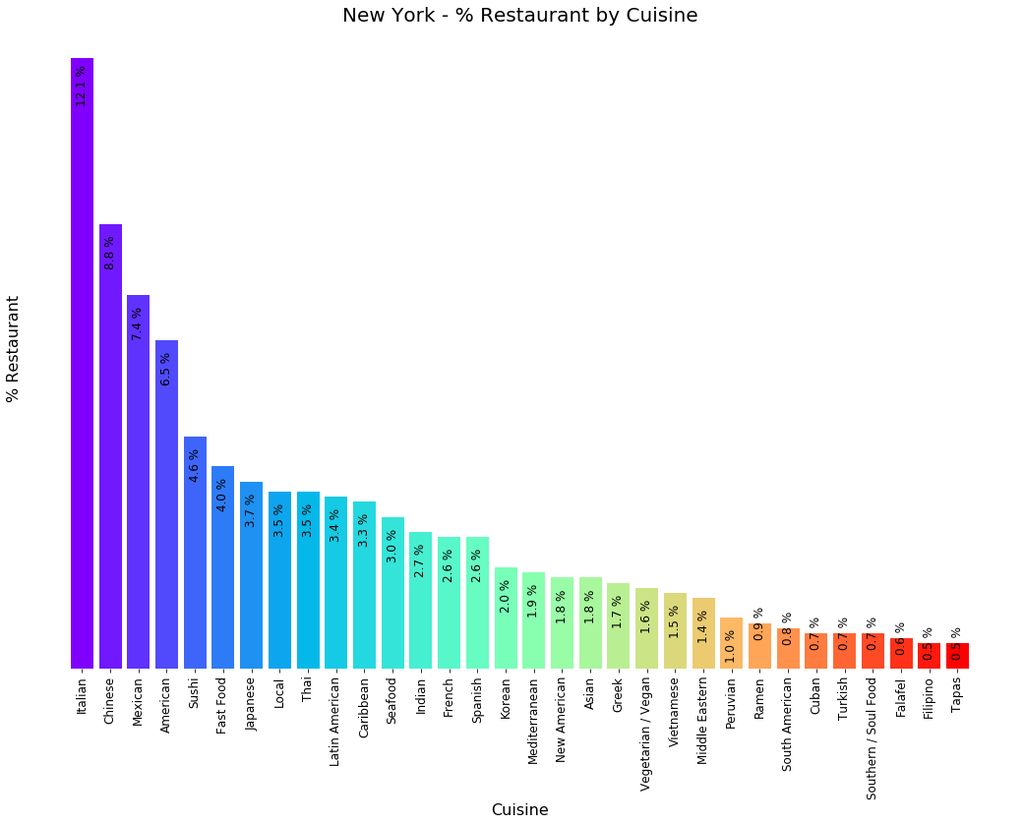

```python
# Bar Graph for % of Restaurants serving different cuisine in New York.
```

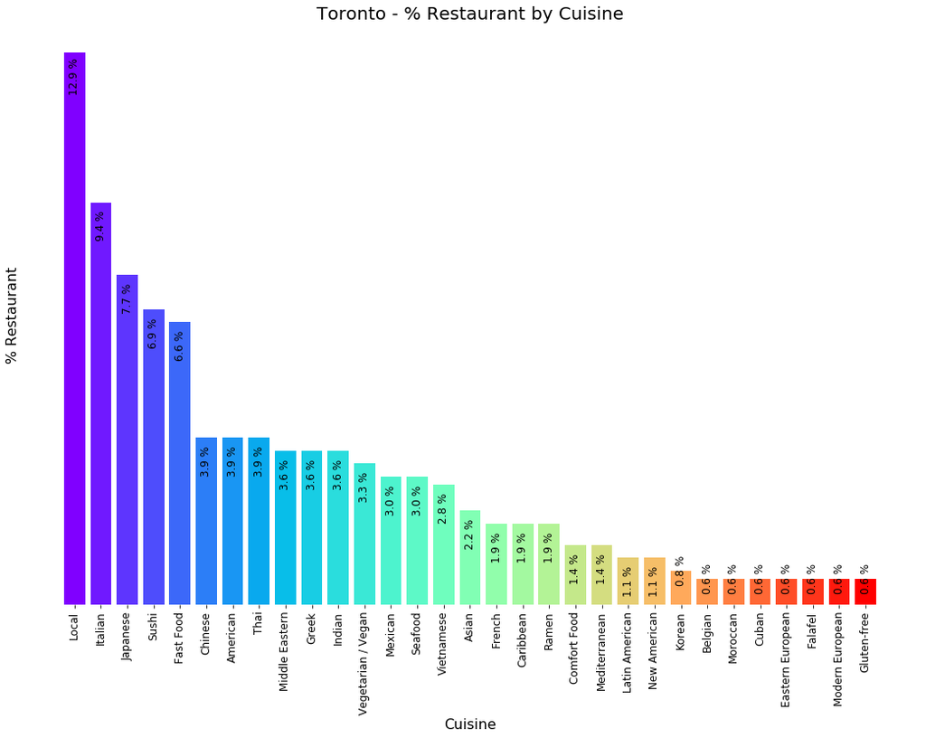

```python
# Bar Graph for % of Restaurants serving different cuisine in Toronto.
```

*Looking at distribution of restaurants by cuisine they serve, we can conclude that both cities have restaurants serving cuisines famous across the globe. Note, In similar way we can compare cities according venues categories and check availability of venues.*

*Next, let's visualise the venues serving **India Cuisine** on Map for both the cities.*

**Map of Toronto venues having Indian Restaurant.**

```python
!wget -q -r 'map1.html' https://raw.githubusercontent.com/Dharmeshpatel25Sep/Coursera-Capstone/master/Indian_Restaurants_to.html
IFrame(src = 'map1.html', width=900, height=600)
```

[interactive chart not shown]

```python
#import IPython ; #IPython.display.HTML(filename='Indian Restaurants in Toronto.html')
```

**Map of New York venues having Indian Restaurant.**

```python
!wget -q -O 'map2.html' https://raw.githubusercontent.com/Dharmeshpatel25Sep/Coursera-Capstone/master/Indian_Restaurants_ny.html
IFrame(src='map2.html', width=900, height=600)
```

[interactive chart not shown]

*We can see that both the city has Indian restaurants which is spread across city and New York has much more number of Indian restaurants than Toronto. Now, I will move further to the next analysis of neighborhoods.*

### 4.2 Neighborhood Level Analysis:

**Comparison of Neighborhood based on top 10 Venue Categories**

*I have taken a subset of neighborhoods for analysis as defined in scope. i.e. neighborhood which has some venues of our choice nearby such as Park, Gym, Market etc..*

```python
# I have taken a subset of neighborhoods for analysis as defined in scope. i.e. neighborhood which has some venues of our choice nearby such as Park, Gym, Market etc...
```

|  | Airport Gate | Airport Lounge | Airport Service | Airport Terminal | American Restaurant | Antique Shop | Aquarium | Arcade | Arepa Restaurant | Argentinian Restaurant | Art Gallery |
| --- | --- | --- | --- | --- | --- | --- | --- | --- | --- | --- | --- |
| 0 | 0.0 | 0.0 | 0.0 | 0.0 | 0.000000 | 0.0 | 0.0 | 0.0 | 0.0 | 0.0 | 0.0 |
| 1 | 0.0 | 0.0 | 0.0 | 0.0 | 0.000000 | 0.0 | 0.0 | 0.0 | 0.0 | 0.0 | 0.0 |
| 2 | 0.0 | 0.0 | 0.0 | 0.0 | 0.015625 | 0.0 | 0.0 | 0.0 | 0.0 | 0.0 | 0.0 |
| 3 | 0.0 | 0.0 | 0.0 | 0.0 | 0.038462 | 0.0 | 0.0 | 0.0 | 0.0 | 0.0 | 0.0 |
| 4 | 0.0 | 0.0 | 0.0 | 0.0 | 0.000000 | 0.0 | 0.0 | 0.0 | 0.0 | 0.0 | 0.0 |

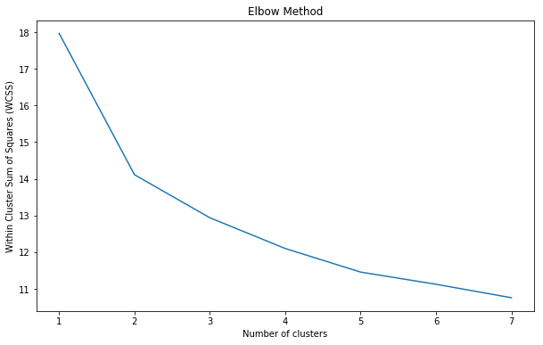

```python
# Find out optimal number of cluster using elbow method, and cluster neighborhood data using.
```

```python
# Finally, I cluster all the neighborhood based on their venues category using K-means into 5 clusters.
```

```
Final Cluster dataframe
```

|  | Cluster Labels | City | Neighborhood | Latitude | Longitude | 1st Most Common Vcat | 2nd Most Common Vcat | 3rd Most Common Vcat | 4th Most Common Vcat | 5th Most Common Vcat | 6th Most Common Vcat | 7th Most Common Vcat | 8th Most Common Vcat | 9th Most Common Vcat | 10th Most Common Vcat |
| --- | --- | --- | --- | --- | --- | --- | --- | --- | --- | --- | --- | --- | --- | --- | --- |
| 0 | 4 | New York | Allerton | 40.865788 | -73.859319 | Pizza Place | Supermarket | Bus Station | Deli / Bodega | Breakfast Spot | Dessert Shop | Bakery | Chinese Restaurant | Gym / Fitness Center | Gas Station |
| 1 | 1 | New York | Arden Heights | 40.549286 | -74.185887 | Pizza Place | Deli / Bodega | Pharmacy | Coffee Shop | Dry Cleaner | Fish & Chips Shop | Financial or Legal Service | Duty-free Shop | Eastern European Restaurant | Egyptian Restaurant |
| 2 | 4 | New York | Battery Park City | 40.711932 | -74.016869 | Park | Hotel | Coffee Shop | Gym | Memorial Site | Food Court | Boat or Ferry | Burger Joint | Gourmet Shop | Plaza |
| 3 | 4 | New York | Bayside | 40.766041 | -73.774274 | Bar | Pizza Place | Indian Restaurant | American Restaurant | Sushi Restaurant | Cosmetics Shop | Greek Restaurant | Steakhouse | Spa | Italian Restaurant |
| 4 | 1 | New York | Bedford Stuyvesant | 40.687232 | -73.941785 | Coffee Shop | Café | Deli / Bodega | Bar | Pizza Place | Fried Chicken Joint | Bus Stop | Gift Shop | Gourmet Shop | Juice Bar |

```python
# Overview, how the clustering have classified similar neighborhoods across city ?.
```

| Cluster Labels | City | Neighborhood |
| --- | --- | --- |
| 0 | New York | 10 |
|  | Toronto | 1 |
| 1 | New York | 8 |
|  | Toronto | 19 |
| 2 | New York | 2 |
|  | Toronto | 3 |
| 3 | New York | 2 |
|  | Toronto | 8 |
| 4 | New York | 39 |
|  | Toronto | 13 |

*We can see that each cluster has one or more neighbourhoods from both the city, which suggest that in our dataset we have match for every neigborhood in both the city.*

**Examine Clusters**

*Now, I can examine cluster assigned to Neighborhood and determine the discriminating venue categories that distinguish it from other cluster and I can also find similar neighborhood by cluster label.*

```python
# Taking few rows of cluster # 4 to examine.
```

|  | City | Neighborhood | 1st Most Common Vcat | 2nd Most Common Vcat | 3rd Most Common Vcat | 4th Most Common Vcat | 5th Most Common Vcat | 6th Most Common Vcat | 7th Most Common Vcat | 8th Most Common Vcat | 9th Most Common Vcat | 10th Most Common Vcat |
| --- | --- | --- | --- | --- | --- | --- | --- | --- | --- | --- | --- | --- |
| 76 | Toronto | Golden Mile, Clairlea, Oakridge | Bakery | Bus Line | Ice Cream Shop | Park | Metro Station | Yoga Studio | Eye Doctor | Egyptian Restaurant | Electronics Store | Empanada Restaurant |
| 56 | New York | Starrett City | Bus Station | Supermarket | Pharmacy | Pizza Place | American Restaurant | Donut Shop | Bus Stop | Caribbean Restaurant | Convenience Store | English Restaurant |
| 80 | Toronto | Kennedy Park, Ionview, East Birchmount Park | Discount Store | Convenience Store | Department Store | Bus Station | Train Station | Coffee Shop | Hobby Shop | Chinese Restaurant | Cycle Studio | Cosmetics Shop |
| 90 | Toronto | Steeles West, L'Amoreaux West | Fast Food Restaurant | Chinese Restaurant | Breakfast Spot | Grocery Store | Sandwich Place | Pharmacy | Coffee Shop | Pizza Place | Bank | Supermarket |
| 68 | Toronto | Davisville North | Food & Drink Shop | Hotel | Gym / Fitness Center | Park | Sandwich Place | Department Store | Gym | Breakfast Spot | Filipino Restaurant | Entertainment Service |
| 66 | Toronto | Christie | Grocery Store | Café | Park | Restaurant | Candy Store | Coffee Shop | Diner | Baby Store | Italian Restaurant | Nightclub |
| 69 | Toronto | Dorset Park, Wexford Heights, Scarborough Town... | Indian Restaurant | Chinese Restaurant | Brewery | Pet Store | Furniture / Home Store | Vietnamese Restaurant | Exhibit | Eastern European Restaurant | Egyptian Restaurant | Electronics Store |
| 95 | Toronto | Thorncliffe Park | Indian Restaurant | Sandwich Place | Yoga Studio | Supermarket | Coffee Shop | Discount Store | Pharmacy | Middle Eastern Restaurant | Gas Station | Restaurant |
| 75 | Toronto | Glencairn | Metro Station | Pub | Japanese Restaurant | Asian Restaurant | Yoga Studio | Eastern European Restaurant | Egyptian Restaurant | Electronics Store | Empanada Restaurant | English Restaurant |
| 57 | New York | Stuyvesant Town | Park | Gas Station | Bistro | Bar | Gym / Fitness Center | Skating Rink | Pet Service | Harbor / Marina | Cocktail Bar | Coffee Shop |
| 70 | Toronto | Downsview | Park | Airport | Electronics Store | Snack Place | Yoga Studio | Eye Doctor | Eastern European Restaurant | Egyptian Restaurant | Empanada Restaurant | English Restaurant |
| 78 | Toronto | Humewood-Cedarvale | Park | Trail | Field | Hockey Arena | Yoga Studio | Exhibit | Duty-free Shop | Eastern European Restaurant | Egyptian Restaurant | Electronics Store |
| 79 | Toronto | India Bazaar, The Beaches West | Park | Pizza Place | Sandwich Place | Fast Food Restaurant | Fish & Chips Shop | Liquor Store | Brewery | Gym | Pet Store | Restaurant |
| 102 | Toronto | Woodbine Heights | Park | Curling Ice | Pharmacy | Video Store | Athletics & Sports | Skating Rink | Spa | Beer Store | English Restaurant | Empanada Restaurant |
| 74 | Toronto | Forest Hill North & West, Forest Hill Road Park | Trail | Park | Sushi Restaurant | Jewelry Store | Eye Doctor | Duty-free Shop | Eastern European Restaurant | Egyptian Restaurant | Electronics Store | Empanada Restaurant |

*We can see from above results that one of Toronto the neighborhood **Thorncliffe Park** has match with few of the neighborhood in New York. I tried to find out more about other match of this neighborhood with in Toronto and in New York.*

```python
# Match of "Thorncliffe Park" neighborhood within Toronto city.
```

|  | City | Neighborhood | 1st Most Common Vcat | 2nd Most Common Vcat | 3rd Most Common Vcat | 4th Most Common Vcat | 5th Most Common Vcat | 6th Most Common Vcat | 7th Most Common Vcat | 8th Most Common Vcat | 9th Most Common Vcat | 10th Most Common Vcat |
| --- | --- | --- | --- | --- | --- | --- | --- | --- | --- | --- | --- | --- |
| 76 | Toronto | Golden Mile, Clairlea, Oakridge | Bakery | Bus Line | Ice Cream Shop | Park | Metro Station | Yoga Studio | Eye Doctor | Egyptian Restaurant | Electronics Store | Empanada Restaurant |
| 80 | Toronto | Kennedy Park, Ionview, East Birchmount Park | Discount Store | Convenience Store | Department Store | Bus Station | Train Station | Coffee Shop | Hobby Shop | Chinese Restaurant | Cycle Studio | Cosmetics Shop |
| 90 | Toronto | Steeles West, L'Amoreaux West | Fast Food Restaurant | Chinese Restaurant | Breakfast Spot | Grocery Store | Sandwich Place | Pharmacy | Coffee Shop | Pizza Place | Bank | Supermarket |
| 68 | Toronto | Davisville North | Food & Drink Shop | Hotel | Gym / Fitness Center | Park | Sandwich Place | Department Store | Gym | Breakfast Spot | Filipino Restaurant | Entertainment Service |
| 66 | Toronto | Christie | Grocery Store | Café | Park | Restaurant | Candy Store | Coffee Shop | Diner | Baby Store | Italian Restaurant | Nightclub |
| 69 | Toronto | Dorset Park, Wexford Heights, Scarborough Town... | Indian Restaurant | Chinese Restaurant | Brewery | Pet Store | Furniture / Home Store | Vietnamese Restaurant | Exhibit | Eastern European Restaurant | Egyptian Restaurant | Electronics Store |
| 95 | Toronto | Thorncliffe Park | Indian Restaurant | Sandwich Place | Yoga Studio | Supermarket | Coffee Shop | Discount Store | Pharmacy | Middle Eastern Restaurant | Gas Station | Restaurant |
| 75 | Toronto | Glencairn | Metro Station | Pub | Japanese Restaurant | Asian Restaurant | Yoga Studio | Eastern European Restaurant | Egyptian Restaurant | Electronics Store | Empanada Restaurant | English Restaurant |
| 70 | Toronto | Downsview | Park | Airport | Electronics Store | Snack Place | Yoga Studio | Eye Doctor | Eastern European Restaurant | Egyptian Restaurant | Empanada Restaurant | English Restaurant |
| 78 | Toronto | Humewood-Cedarvale | Park | Trail | Field | Hockey Arena | Yoga Studio | Exhibit | Duty-free Shop | Eastern European Restaurant | Egyptian Restaurant | Electronics Store |
| 79 | Toronto | India Bazaar, The Beaches West | Park | Pizza Place | Sandwich Place | Fast Food Restaurant | Fish & Chips Shop | Liquor Store | Brewery | Gym | Pet Store | Restaurant |
| 102 | Toronto | Woodbine Heights | Park | Curling Ice | Pharmacy | Video Store | Athletics & Sports | Skating Rink | Spa | Beer Store | English Restaurant | Empanada Restaurant |
| 74 | Toronto | Forest Hill North & West, Forest Hill Road Park | Trail | Park | Sushi Restaurant | Jewelry Store | Eye Doctor | Duty-free Shop | Eastern European Restaurant | Egyptian Restaurant | Electronics Store | Empanada Restaurant |

*I found 12 match for neighborhood within Toronto, Next I checked for neighborhood match in New York.*

```python
# Match for Toronoto neighborhood named "Thorncliffe Park" in New York city.
```

|  | City | Neighborhood | 1st Most Common Vcat | 2nd Most Common Vcat | 3rd Most Common Vcat | 4th Most Common Vcat | 5th Most Common Vcat | 6th Most Common Vcat | 7th Most Common Vcat | 8th Most Common Vcat | 9th Most Common Vcat | 10th Most Common Vcat |
| --- | --- | --- | --- | --- | --- | --- | --- | --- | --- | --- | --- | --- |
| 25 | New York | Greenridge | Bagel Shop | Diner | Shipping Store | Lawyer | Asian Restaurant | Pizza Place | Duty-free Shop | Eastern European Restaurant | Egyptian Restaurant | Electronics Store |
| 17 | New York | Dyker Heights | Bagel Shop | Park | Grocery Store | Golf Course | Burger Joint | Eye Doctor | Egyptian Restaurant | Electronics Store | Empanada Restaurant | English Restaurant |
| 28 | New York | Hollis | Bakery | Park | Mobile Phone Shop | Baseball Field | Chinese Restaurant | Shopping Mall | Electronics Store | Sandwich Place | Asian Restaurant | Discount Store |
| 30 | New York | Huguenot | Bank | Ice Cream Shop | Deli / Bodega | Bridal Shop | Nail Salon | Donut Shop | Sandwich Place | Train Station | Asian Restaurant | Moving Target |
| 3 | New York | Bayside | Bar | Pizza Place | Indian Restaurant | American Restaurant | Sushi Restaurant | Cosmetics Shop | Greek Restaurant | Steakhouse | Spa | Italian Restaurant |
| 56 | New York | Starrett City | Bus Station | Supermarket | Pharmacy | Pizza Place | American Restaurant | Donut Shop | Bus Stop | Caribbean Restaurant | Convenience Store | English Restaurant |
| 44 | New York | Pomonok | Bus Station | Supermarket | Bar | Pizza Place | Halal Restaurant | Japanese Restaurant | Scenic Lookout | Playground | Park | Bowling Alley |
| 12 | New York | Claremont Village | Bus Station | Grocery Store | Bakery | Park | Deli / Bodega | Gym | Liquor Store | Chinese Restaurant | Caribbean Restaurant | Gift Shop |
| 42 | New York | Park Hill | Bus Stop | Gym / Fitness Center | Park | Hotel | Athletics & Sports | Coffee Shop | Exhibit | Eastern European Restaurant | Egyptian Restaurant | Electronics Store |
| 39 | New York | New Brighton | Bus Stop | Park | Deli / Bodega | Playground | Discount Store | Bowling Alley | Bridal Shop | Botanical Garden | Fish Market | Eye Doctor |
| 40 | New York | Olinville | Caribbean Restaurant | Liquor Store | Fried Chicken Joint | Basketball Court | Deli / Bodega | Furniture / Home Store | Food | Supermarket | Financial or Legal Service | Egyptian Restaurant |
| 33 | New York | Laurelton | Caribbean Restaurant | Cosmetics Shop | Park | Train Station | Yoga Studio | Exhibit | Eastern European Restaurant | Egyptian Restaurant | Electronics Store | Empanada Restaurant |
| 10 | New York | Canarsie | Chinese Restaurant | Gym | Caribbean Restaurant | Asian Restaurant | Yoga Studio | Dumpling Restaurant | Eastern European Restaurant | Egyptian Restaurant | Electronics Store | Empanada Restaurant |
| 32 | New York | Jamaica Hills | Chinese Restaurant | Pharmacy | Indian Restaurant | Fast Food Restaurant | Fried Chicken Joint | Donut Shop | Southern / Soul Food Restaurant | Mexican Restaurant | Metro Station | Shopping Mall |
| 5 | New York | Bellaire | Convenience Store | Deli / Bodega | Moving Target | Bus Station | Greek Restaurant | Gym | Chinese Restaurant | Coffee Shop | Breakfast Spot | Italian Restaurant |
| 29 | New York | Holliswood | Convenience Store | Playground | Donut Shop | Sandwich Place | Mobile Phone Shop | Bus Line | Supermarket | Financial or Legal Service | Event Space | Eastern European Restaurant |
| 35 | New York | Mariner's Harbor | Deli / Bodega | Italian Restaurant | Supermarket | Athletics & Sports | Yoga Studio | Ethiopian Restaurant | Exhibit | Event Space | Event Service | English Restaurant |
| 14 | New York | College Point | Deli / Bodega | Latin American Restaurant | Bus Station | Pizza Place | Steakhouse | Bar | Asian Restaurant | Seafood Restaurant | Caribbean Restaurant | Donut Shop |
| 41 | New York | Paerdegat Basin | Food | Auto Garage | Asian Restaurant | Yoga Studio | Eye Doctor | Eastern European Restaurant | Egyptian Restaurant | Electronics Store | Empanada Restaurant | English Restaurant |
| 18 | New York | Edenwald | Grocery Store | Supermarket | Chinese Restaurant | Scenic Lookout | Deli / Bodega | Exhibit | Duty-free Shop | Eastern European Restaurant | Egyptian Restaurant | Electronics Store |
| 37 | New York | Mott Haven | Gym | Spanish Restaurant | Donut Shop | Pizza Place | Fish & Chips Shop | Mobile Phone Shop | Grocery Store | Peruvian Restaurant | Latin American Restaurant | Pharmacy |
| 7 | New York | Bergen Beach | Harbor / Marina | Park | Baseball Field | Athletics & Sports | Playground | Yoga Studio | Exhibit | Eastern European Restaurant | Egyptian Restaurant | Electronics Store |
| 21 | New York | Floral Park | Indian Restaurant | Basketball Court | Grocery Store | Dosa Place | Pizza Place | Nail Salon | Fish Market | Event Space | Flower Shop | Egyptian Restaurant |
| 31 | New York | Jamaica Estates | Indian Restaurant | Intersection | Dog Run | Bus Station | Lounge | Eye Doctor | Eastern European Restaurant | Egyptian Restaurant | Electronics Store | Empanada Restaurant |
| 19 | New York | Edgemere | Metro Station | Park | Scenic Lookout | Deli / Bodega | Pizza Place | Bus Station | Skate Park | Farm | Asian Restaurant | Gift Shop |
| 54 | New York | South Ozone Park | Park | Deli / Bodega | Bar | Food Truck | Donut Shop | Hotel | Sandwich Place | Fast Food Restaurant | English Restaurant | Ethiopian Restaurant |
| 55 | New York | Spuyten Duyvil | Park | Tennis Court | Grocery Store | Bank | Thai Restaurant | Intersection | Pharmacy | Tennis Stadium | Pizza Place | Empanada Restaurant |
| 46 | New York | Riverdale | Park | Bus Station | Medical Supply Store | Bank | Gym | Home Service | Plaza | Event Service | Ethiopian Restaurant | Entertainment Service |
| 57 | New York | Stuyvesant Town | Park | Gas Station | Bistro | Bar | Gym / Fitness Center | Skating Rink | Pet Service | Harbor / Marina | Cocktail Bar | Coffee Shop |
| 23 | New York | Glen Oaks | Park | Department Store | Shoe Store | Bank | Mattress Store | Bagel Shop | Grocery Store | Donut Shop | Sandwich Place | Clothing Store |
| 22 | New York | Fulton Ferry | Park | Scenic Lookout | American Restaurant | Ice Cream Shop | Roof Deck | Coffee Shop | Bridge | Bakery | Playground | Pizza Place |
| 2 | New York | Battery Park City | Park | Hotel | Coffee Shop | Gym | Memorial Site | Food Court | Boat or Ferry | Burger Joint | Gourmet Shop | Plaza |
| 11 | New York | Castle Hill | Pizza Place | Bank | Pharmacy | Bus Station | Latin American Restaurant | Diner | Market | English Restaurant | Entertainment Service | Eye Doctor |
| 24 | New York | Grant City | Pizza Place | Fast Food Restaurant | Food & Drink Shop | Bar | Grocery Store | BBQ Joint | Tanning Salon | Event Space | Health & Beauty Service | Asian Restaurant |
| 0 | New York | Allerton | Pizza Place | Supermarket | Bus Station | Deli / Bodega | Breakfast Spot | Dessert Shop | Bakery | Chinese Restaurant | Gym / Fitness Center | Gas Station |
| 9 | New York | Briarwood | Playground | Deli / Bodega | Convenience Store | Coffee Shop | Arts & Crafts Store | Bus Station | Indian Restaurant | Fish & Chips Shop | Flower Shop | Egyptian Restaurant |
| 47 | New York | Rochdale | Southern / Soul Food Restaurant | Market | Pet Store | Bank | Laundromat | Bus Stop | Candy Store | Sandwich Place | Chinese Restaurant | Donut Shop |
| 43 | New York | Parkchester | Supermarket | Pizza Place | American Restaurant | Asian Restaurant | Kids Store | Grocery Store | Bank | Gym / Fitness Center | Gym | Sandwich Place |
| 16 | New York | Corona | Supermarket | Mexican Restaurant | Ice Cream Shop | Deli / Bodega | South American Restaurant | Empanada Restaurant | Basketball Court | Bakery | Park | Donut Shop |

**Neighborhood match of Thorncliffe Park, Toronto in New York City**

```python
!wget -q -O 'map3.html' https://raw.githubusercontent.com/Dharmeshpatel25Sep/Coursera-Capstone/master/Match_Thorncliffe_ny.html
IFrame(src='map3.html', width=900, height=600)
```

[interactive chart not shown]

*Above map shows New York neighborhoods spread through out city, which are like the one of our selected neighborhood (from cluster # 4) of Toronto. in same manner we can compare the likelihood of neighborhoods.*

*Finally, I will plot cluster to see how the neighborhoods cluster are spread within city. let's visualize the clustering of Neighborhood for New York City.*

**Map of Neighborhood cluster for New York City**

```python
!wget -q -O 'map3.html' https://raw.githubusercontent.com/Dharmeshpatel25Sep/Coursera-Capstone/master/Neighborhood_cluster_ny.html
IFrame(src='map3.html', width=900, height=600)
```

[interactive chart not shown]

*Above map gives idea how the chosen cluster # 4 (marked with blue circle) differs from other cluster in our dataset. although every neighborhood has the few venues of our choice yet some are very distinct due to its proximity to specific venues near by such as having beach (marked with green circle, cluster # 0). let's query cluster # 0 to validate the same.*

```python
# Examine neighborhoods of cluster # 0.
```

```
Neighborhood data for cluster # 0
```

|  | City | Neighborhood | 1st Most Common Vcat | 2nd Most Common Vcat | 3rd Most Common Vcat | 4th Most Common Vcat | 5th Most Common Vcat | 6th Most Common Vcat | 7th Most Common Vcat | 8th Most Common Vcat | 9th Most Common Vcat | 10th Most Common Vcat |
| --- | --- | --- | --- | --- | --- | --- | --- | --- | --- | --- | --- | --- |
| 6 | New York | Belle Harbor | Beach | Pub | Deli / Bodega | Spa | Boutique | Mexican Restaurant | Bakery | Chinese Restaurant | Donut Shop | Pharmacy |
| 8 | New York | Breezy Point | Beach | Bus Stop | Supermarket | Monument / Landmark | Trail | Yoga Studio | Electronics Store | Empanada Restaurant | English Restaurant | Entertainment Service |
| 26 | New York | Hammels | Beach | Diner | Fast Food Restaurant | Dog Run | Shoe Store | Bus Stop | Bus Station | Deli / Bodega | Gym / Fitness Center | Fried Chicken Joint |
| 38 | New York | Neponsit | Beach | Beach Bar | Yoga Studio | Factory | Egyptian Restaurant | Electronics Store | Empanada Restaurant | English Restaurant | Entertainment Service | Ethiopian Restaurant |
| 48 | New York | Rockaway Beach | Beach | Food Truck | Deli / Bodega | Bagel Shop | Seafood Restaurant | Arepa Restaurant | Latin American Restaurant | BBQ Joint | Ice Cream Shop | Pizza Place |
| 49 | New York | Rockaway Park | Beach | Donut Shop | Pizza Place | Ice Cream Shop | Pharmacy | Seafood Restaurant | Liquor Store | Bar | Bank | Bagel Shop |
| 53 | New York | South Beach | Beach | Deli / Bodega | Pier | Athletics & Sports | Yoga Studio | Eye Doctor | Egyptian Restaurant | Electronics Store | Empanada Restaurant | English Restaurant |
| 36 | New York | Midland Beach | Bus Stop | Beach | Russian Restaurant | Liquor Store | Bookstore | Deli / Bodega | Restaurant | Pet Store | Ethiopian Restaurant | Event Space |
| 93 | Toronto | The Beaches | Pub | Trail | Health Food Store | Beach | Yoga Studio | Exhibit | Duty-free Shop | Eastern European Restaurant | Egyptian Restaurant | Electronics Store |
| 51 | New York | Sea Gate | Spa | Beach | Home Service | Bus Station | American Restaurant | Exhibit | Event Space | Event Service | Yoga Studio | Factory |
| 50 | New York | Roxbury | Trail | Irish Pub | Deli / Bodega | Baseball Field | Beach | Fast Food Restaurant | Ethiopian Restaurant | Event Space | Event Service | Yoga Studio |

*As expected neighborhood in cluster # 0 are the one which have beach nearby and that specific venue sets them apart from neighborhoods of other clusters, also we can observe a match of similar neighborhood in Toronto which shares a same cluster label. i.e. (#93: The Beaches, Toronto).*

## 5. Results and Discussion:

*After collecting location data for all neighborhoods of both the city, We got a list of 15 boroughs and 401 neighborhoods. which consist 302 of New York and 99 neighborhoods of Toronto. as we know New York is bigger than Toronto in area and the count of neighborhood apparently suggest that it is much more dense, further search on web suggest that its because of huge difference in population of both the cities.*

| City | Area | Population |
| --- | --- | --- |
| **Toronto** | 630.2 km² | 29.3 lakhs |
| **NewYork** | 783.8 km² | 84 lakhs |

*However, as our objective is to analyze the kind of neighborhoods (based on venues categories) that both the city has to offer , I fetched the venues with in 500 meter radius of each neighborhood from Foursquare API and cleaned them, I obtained total **11,975 venues**, which includes duplicates of ~900 venues which are with in radius of more then neighborhood, I further explored the data and transformed it in standard format for analysis.*

**Unique counts after cleaning:**

| City | #Neighborhoods | #Venues | #Categories |
| --- | --- | --- | --- |
| **Toronto** | 95 | 1,639 | 264 |
| **NewYork** | 301 | 9,422 | 428 |

**Comparison of Cities based on Venue Categories:**

*Given that New York has way too more venues compare to Toronto, and has more venue categories. To see how the venue categories are distributed. I mapped venue categories to more general category and compared the contribution of general venue categories of both the cities.*

- *We found that these cities are very similar and has almost identical contribution of venue categories. The majority of venues falls in to top 2 categories which contributes to ~75% of venues, where ~52% venues falls in to Food and ~23% into Shop & Services category for both the cities.*
- *We then plotted distribution of restaurants by cuisine they serve, and concluded that both cities have restaurants serving cuisines famous across the globe. We also created a map of venues for Indian restaurants for both the cities which showed us that Indian restaurants spread across city and not concentrated around any single neighborhood.*

**Comparison of Neighborhood based on top 10 Venue Categories:**

*For Neighborhood comparison analysis I took a subset of neighborhood from both the cities, having at least one top venue in below mentioned categories, I found 105 neighborhood, 61 of New York and 44 of Toronto, and classified them in 5 cluster using K-Means based on their top venue categories.*

> *Filtered neighborhood having any of the following category : Gym, Park, Arts & Entertainment, Beach, Coffee Shop, Sports Bar, Market, Supermarket, Asian Restaurant, Indian Restaurant.*
- *We found that each cluster has mix of neighborhoods from both the city, and non of the cluster found city specific, which suggest that in our dataset we have match for every neighborhood in both the city.*
- *We took one neighborhood to find match within city as well as in other city and explored them with the help of map and concluded that with this framework we can find and compare neighborhoods*
- *Finally, we plotted neighborhood cluster on map for New York, and examined how the neighborhoods cluster are spread within city and how they differs from other cluster. we took a closure look to one cluster and concluded that although every neighborhood has the few venues of our choice yet some are very distinct due to its proximity to specific venues near by such as having beach and as such sets them apart from neighborhoods of other clusters.*

## 6. Conclusion:

*The purpose of this project was to compare Toronto, Canada and New York city of America, and check likelihood of cities and their neighborhoods by kind of venues they offer and workout the process of comparison of cities and neighborhoods across geographies.*

> *Venues and their details for all the neighborhood have been identified and City and Neighborhood level Exploratory Data Analysis are complete. The results suggest that despite of being on two different geographies and of different size of cities. Both the cities, New York and Toronto shares similar contribution venue types, and has many similar kind of neighborhood which one can choose based on individual interest. we have our framework ready and cleaned/labeled data which we can use any time to query the neighborhood or venues of our choice for both the cities, we can also use this data to suggest neighborhoods to the new person/business to these cities.*

End of Notebook